# SCPCL000822 - Validation of tumor cells

Ally Hawkins

2024-06-14

## Introduction

In this notebook we compare tumor cell annotations obtained from marker genes, `CopyKAT`, and `InferCNV` to identify a group of tumor cells we are confident in.

- First we look at the cells that are annotated as tumor cells by each method. Using this information, we call any cell that is annotated as a tumor cell by both `CopyKAT` and `InferCNV` as a tumor cell.
- We then validate that these are in fact tumor cells by doing the following:
  - Looking at marker gene expression.
  - Looking at expression of EWS-FLI1 target gene sets.
  - Confirming presence of known CNVs in Ewing sarcoma

## Setup

```r
suppressPackageStartupMessages({
  # load required packages
  library(SingleCellExperiment)
  library(ggplot2)
})

# Set default ggplot theme
theme_set(
  theme_bw()
)

# use jpegs for images
knitr::opts_chunk$set(
  dev = "jpeg"
)

# quiet messages
options(readr.show_col_types = FALSE)
ComplexHeatmap::ht_opt(message = FALSE)
```

```r
# The base path for the OpenScPCA repository, found by its (hidden) .git directory
repository_base <- rprojroot::find_root(rprojroot::is_git_root)

# The current data directory, found within the repository base directory
data_dir <- file.path(repository_base, "data", "2024-05-01")
sample_dir <- file.path(data_dir, "SCPCP000015", "SCPCS000490")

# The path to this module
module_base <- file.path(repository_base, "analyses", "cell-type-ewings")
```

```r
# source in helper functions: plot_gene_heatmap() and plot_cnv_heatmap()
# create_classification_df() and create_marker_gene_df()
validation_functions <- file.path(module_base, "scripts", "utils", "tumor-validation-helpers.R")
source(validation_functions)
```

```r
# Input files
sce_file <- file.path(sample_dir, "SCPCL000822_processed.rds")
marker_genes_file <- file.path(module_base, "references", "tumor-marker-genes.tsv")

# results from annotation workflow
results_dir <- file.path(module_base, "results", "annotate_tumor_cells_output", "SCPCS000490")

marker_gene_results_file <- file.path(results_dir, "SCPCL000822_tumor-normal-classifications.tsv")
copykat_predictions_file <- file.path(results_dir, "SCPCL000822_copykat-classifications.tsv")

infercnv_predictions_file <- file.path(results_dir, "SCPCL000822_infercnv-classifications.tsv")
infercnv_metadata_file <- file.path(results_dir, "infercnv", "SCPCL000822_cnv-metadata.tsv")

geneset_scores_file <- file.path(results_dir, "SCPCL000822_gene-set-scores.tsv")

# output files
final_annotations_dir <- file.path(module_base, "cell_type_annotations", "SCPCS000490")
fs::dir_create(final_annotations_dir)
final_annotations_file <- file.path(final_annotations_dir, "SCPCL000822_tumor-classifications.tsv")
```

### Process input files

```r
# read in sce file
sce <- readr::read_rds(sce_file)
```

```r
# generate classification df
classification_df <- create_classification_df(
  sce,
  marker_gene_results_file,
  copykat_predictions_file,
  infercnv_predictions_file,
  infercnv_metadata_file,
  geneset_scores_file
)
```

```r
# generate marker genes df
plot_markers_df <- create_marker_gene_df(
  classification_df,
  marker_genes_file
)
```

## Identify tumor cell population

Below is a UMAP showing which cells are labeled as tumor cells using each of the various classification methods.

- Marker genes only: For each cell, the expression of all marker genes was transformed using a z-transformation and summed together. Any cells with a total marker gene expression value > 0 were called as tumor cells.
- CopyKAT - no reference: [`CopyKAT`](https://github.com/navinlabcode/copykat) was run without indicating any reference cells and cells were classified as aneuploid (Tumor) or diploid (Normal).
- InferCNV - [`InferCNV`](https://github.com/broadinstitute/inferCNV/wiki) was used to call copy number variations using endothelial and fibroblasts assigned by `CellAssign` as the normal reference group. This returns a proportion of each chromosome with a CNV detected. We then calculate the genomic CNV proportion for each cell across all chromosomes, weighted by the number of genes in a chromosome. Cells with a genomic CNV proportion greater than the mean CNV proportion across all cells are called as tumor cells.

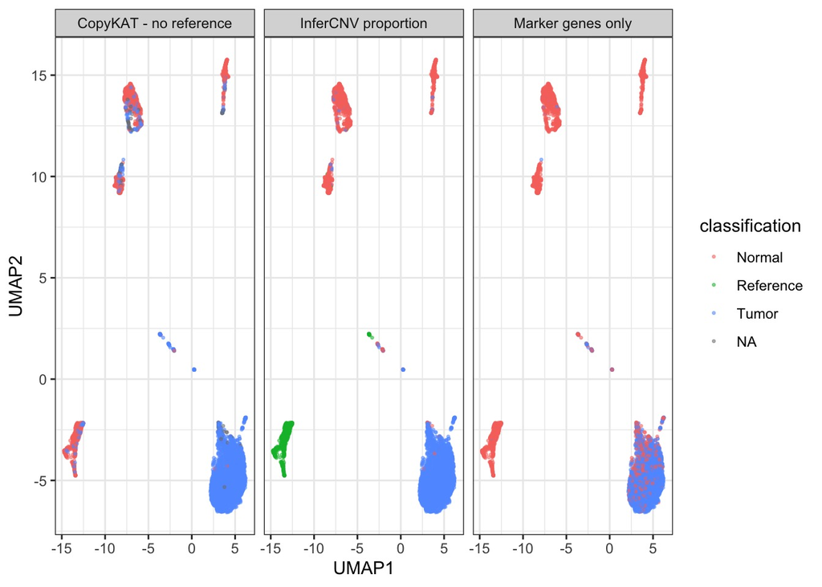

```r
# plot tumor cells for each classification method
tumor_umap_df <- classification_df |>
  dplyr::select(barcodes, UMAP1, UMAP2, marker_gene_classification, copykat_classification, cnv_proportion_classification) |>
  tidyr::pivot_longer(
    cols = ends_with("classification"),
    names_to = "method",
    values_to = "classification"
  ) |>
  dplyr::mutate(
    method = dplyr::case_when(
      method == "marker_gene_classification" ~ "Marker genes only",
      method == "copykat_classification" ~ "CopyKAT - no reference",
      method == "cnv_proportion_classification" ~ "InferCNV proportion"
    )
  )

ggplot(tumor_umap_df, aes(x = UMAP1, UMAP2, color = classification)) +
  geom_point(size = 0.5, alpha = 0.5) +
  facet_wrap(vars(method))
```

This plot shows us that there is a pretty clear consensus that most of the cells in the bottom right group are tumor cells. From the original marker gene analysis we know that not all marker genes are expressed and that there is quite a bit of variance in expression. Because of that and the fact that both CNV inference methods show similar annotations, we will classify any cells that are labeled as tumor by both `CopyKAT` and `InferCNV` as tumor cells.

```r
# create a combined classification between inferCNV and copyKAT
# cells that are classified as tumor by both are kept as tumor
# classified by both as normal are normal
# in between are classified as ambiguous
classification_df <- classification_df |>
  dplyr::mutate(
    combined_cnv_classification = dplyr::case_when(
      # only tumor if both call tumor
      cnv_proportion_classification == "Tumor" & copykat_classification == "Tumor" ~ "Tumor",
      # only normal if both call normal and/or reference
      cnv_proportion_classification == "Normal" & copykat_classification == "Normal" ~ "Normal",
      cnv_proportion_classification == "Reference" & copykat_classification == "Normal" ~ "Normal",
      # if normal/tumor mismatch set to ambiguous
      .default = "Ambiguous"
    ),
    # set factor order to use for plotting
    combined_cnv_classification = forcats::fct_relevel(combined_cnv_classification, "Tumor", "Normal", "Ambiguous"))
```

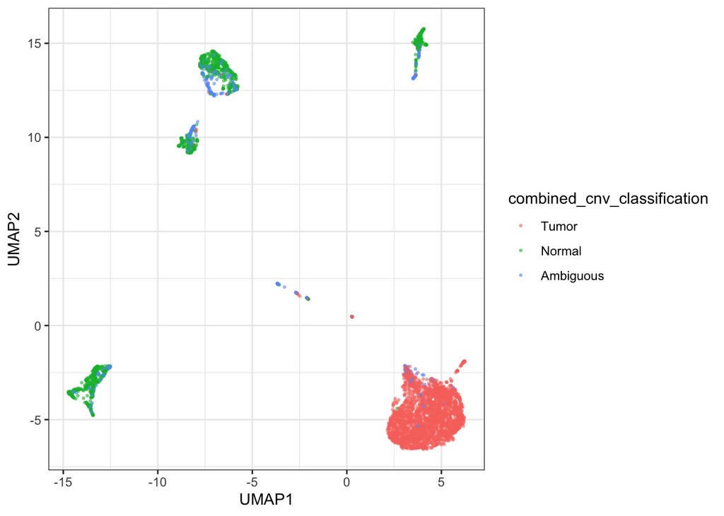

```r
# look at which cells are tumor/normal
# be sure to remove any duplicates
classification_df |>
  dplyr::select(UMAP1, UMAP2, barcodes, combined_cnv_classification) |>
  dplyr::distinct() |>
  ggplot(aes(x = UMAP1, y = UMAP2, color = combined_cnv_classification)) +
  geom_point(alpha = 0.5, size = 0.5)
```

The remainder of the notebook will focus on validating that these in fact are tumor cells and all other cells are classified as normal. We will also look at where the ambiguous cells fall in relation to tumor vs. normal.

## Validate tumor cells

### Marker gene expression

First, we will look at the expression of the tumor marker genes. We expect that these should be expressed higher in the tumor cells than in the normal cells.

Just a note that the `marker_gene_classification` is a circular since these same marker genes were used to classify those cells.

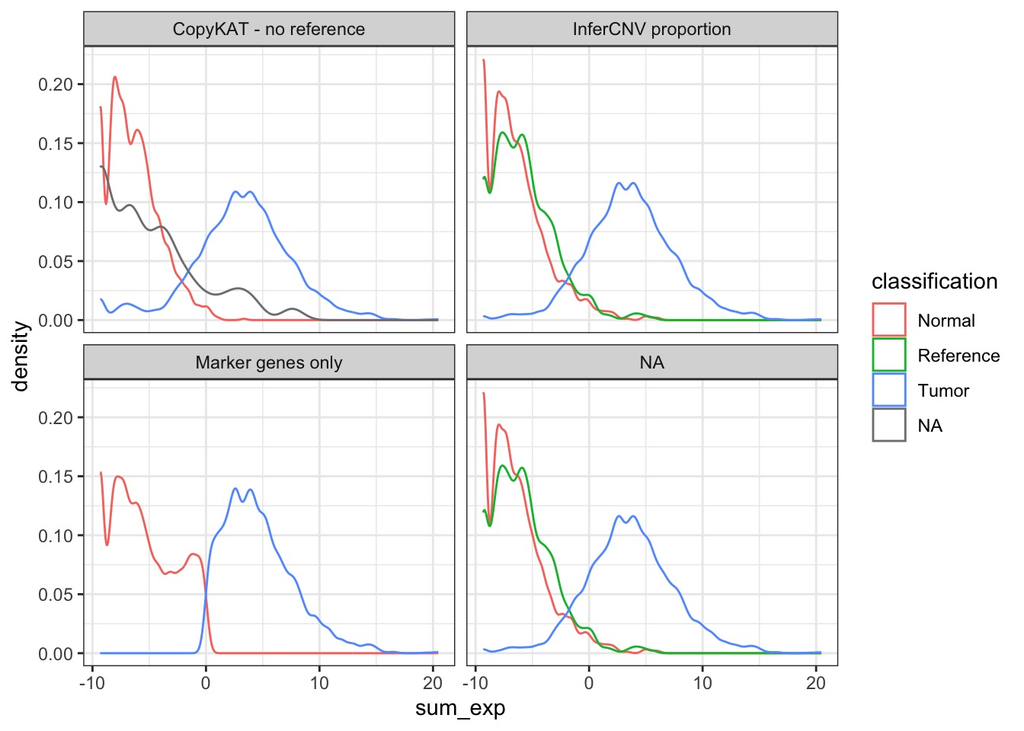

```r
# calculate sum of the scaled gene expression values for plotting
marker_density_df <- plot_markers_df |>
  tidyr::pivot_longer(
    cols = ends_with("classification"),
    names_to = "method",
    values_to = "classification"
  ) |>
  dplyr::mutate(
    method = dplyr::case_when(
      method == "marker_gene_classification" ~ "Marker genes only",
      method == "copykat_classification" ~ "CopyKAT - no reference",
      method == "cnv_proportion_classification" ~ "InferCNV proportion",
      method == "combined_cnv_classification" ~ "CopyKAT and InferCNV"
    )
  )

ggplot(marker_density_df, aes(x = sum_exp, color = classification)) +
  geom_density() +
  facet_wrap(vars(method))
```

Next, we will plot the expression of each gene in each cell using a heatmap. Here the rows are the marker genes and the columns are the cells with the color indicating the expression of that gene in that cell.

```r
# create matrix with marker genes as rows and barcodes as columns
marker_gene_heatmap <- plot_markers_df |>
  dplyr::select(gene_expression, gene_symbol, barcodes) |>
  tidyr::pivot_wider(values_from = gene_expression,
                     names_from = barcodes) |>
  tibble::column_to_rownames("gene_symbol") |>
  as.matrix()

# create annotation df, make sure that dimensions match up by only getting unique barcodes
annotation_df <- classification_df |>
  dplyr::select(barcodes, combined_cnv_classification) |>
  unique()

annotation <- ComplexHeatmap::columnAnnotation(
  classification = annotation_df$combined_cnv_classification,
  col = list(classification = c("Tumor" = "#00274C", "Normal" = "#FFCB05", "Ambiguous" = "grey")))
```

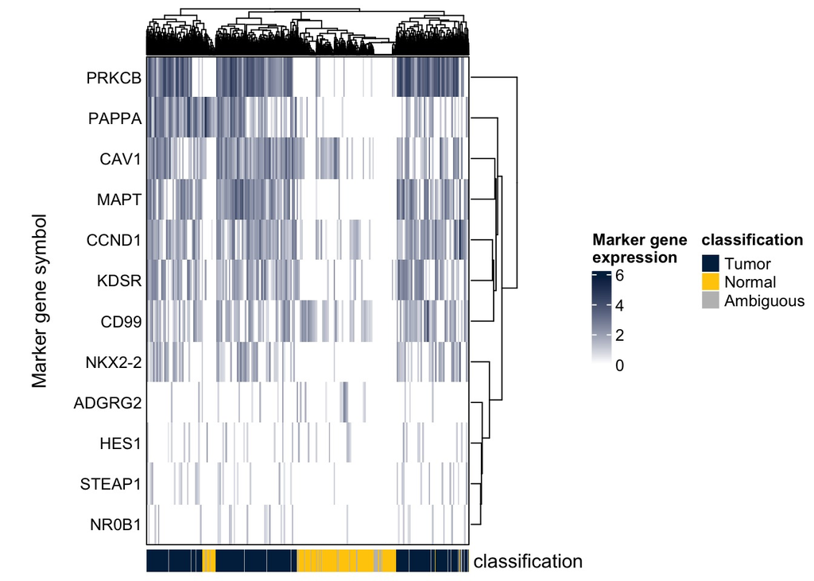

```r
# plot heatmap of marker genes
plot_gene_heatmap(marker_gene_heatmap,
                  row_title = "Marker gene symbol",
                  legend_title = "Marker gene \nexpression",
                  annotation = annotation)
```

As expected, the tumor cells appear to have more marker genes that are expressed than normal cells. The “Ambiguous” cells appear to have a small group of cells that cluster with the tumor cells on the right hand side of the plot.

### Gene set scores

Next, we will look at the gene set scores for three different EWS-FLI1 gene sets. The below plots will all use the `mean-GENESET` columns.

First we will just look at the gene set scores for each cell on the UMAP.

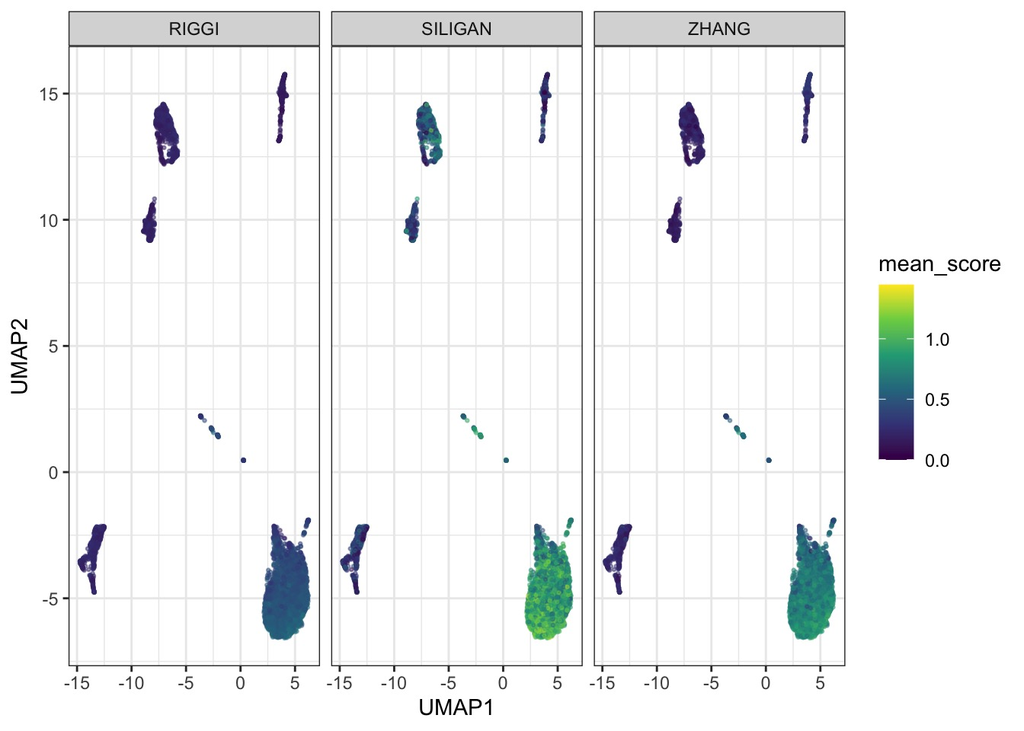

```r
# plot tumor cells for each classification method
geneset_plot_df <- classification_df |>
  dplyr::select(barcodes, UMAP1, UMAP2, ends_with("classification"), starts_with("mean-")) |>
  tidyr::pivot_longer(
    cols = starts_with("mean"),
    names_to = "geneset",
    values_to = "mean_score"
  ) |>
  dplyr::mutate(
    geneset = stringr::word(geneset, -1, sep = "-")
  )

ggplot(geneset_plot_df, aes(x = UMAP1, UMAP2, color = mean_score)) +
  geom_point(size = 0.5, alpha = 0.5) +
  facet_wrap(vars(geneset)) +
  scale_color_viridis_c()
```

Generally, the higher gene set scores appear to be in the group of cells that are tumor cells with some slight variations between gene sets.

Below we look at gene set scores for cells classified as tumor cells vs normal cells for all classification methods.

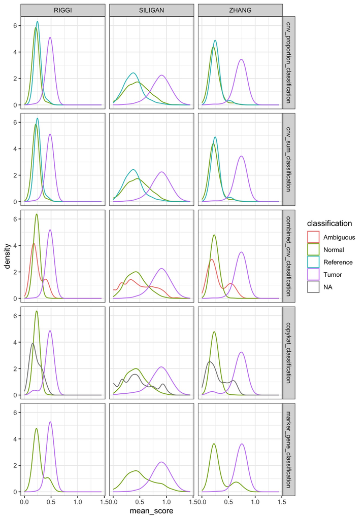

```r
geneset_plot_df |>
  tidyr::pivot_longer(
    cols = ends_with("classification"),
    names_to = "method",
    values_to = "classification"
  ) |>
  ggplot(aes(x = mean_score, color = classification)) +
  geom_density(bw = 0.05) +
  facet_grid(rows = vars(method),
             cols = vars(geneset))
```

For the most part the gene set scores are higher in tumor cells regardless of classification.

We also see that the “Ambiguous” cells identified in the combined classification mostly mirror the gene set expression scores for normal cells with maybe a small group of cells having more similar gene set scores to tumor cells.

Below we make a heatmap of the gene set scores for just the combined CNV classification. Each row is a gene set and each column is a barcode. The color indicates the gene set score for that cell.

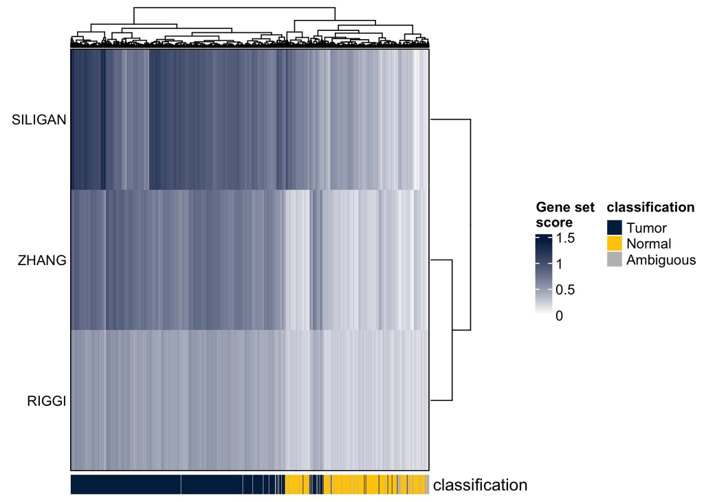

```r
# make a matrix of gene set by barcode
geneset_heatmap <- geneset_plot_df |>
  dplyr::select(mean_score, geneset, barcodes) |>
  unique() |>
  tidyr::pivot_wider(values_from = mean_score,
                     names_from = barcodes) |>
  tibble::column_to_rownames("geneset") |>
  as.matrix()

# plot heatmap of gene set score
plot_gene_heatmap(geneset_heatmap,
                  annotation = annotation,
                  legend_title = "Gene set \nscore")
```

For the most part we see that cells with higher gene set scores are classified as tumor cells. One thing to note is that the `SILIGAN` gene set appears to have some expression in normal cells. However, if you look at the spots where all three gene sets have higher scores, these apply to tumor cells.

Again, most of the “Ambiguous” tumor cells tend to align with normal cells, with a few grouping in the area where cells transition from tumor to normal.

### Validate based on CNAs

The last thing we will do here is look to see if tumor cells have any of the expected CNAs found in Ewing sarcoma:

- Gain of Chr8
- Gain of Chr12
- Gain of Chr1p
- Loss of Chr16q

Although these are the most frequent, there are patients who do not have any of these alterations and patients that only have some of these alterations. See [Tirode et al.,](https://www.ncbi.nlm.nih.gov/pmc/articles/PMC4264969/) and [Crompton et al.](https://doi.org/10.1158/2159-8290.CD-13-1037).

We will look specifically at gains and losses in each chromosome across tumor and normal cells. To do this, we will use the output from `InferCNV` since that output separates out gains and losses in a way that makes it easy for plotting.

The first heatmap looks at the proportion of each chromosome with a CNV that corresponds to an amplification or gain. Here each row is a cell and each column is a chromosome with the color corresponding to the proportion of the chromosome with a gain detected.

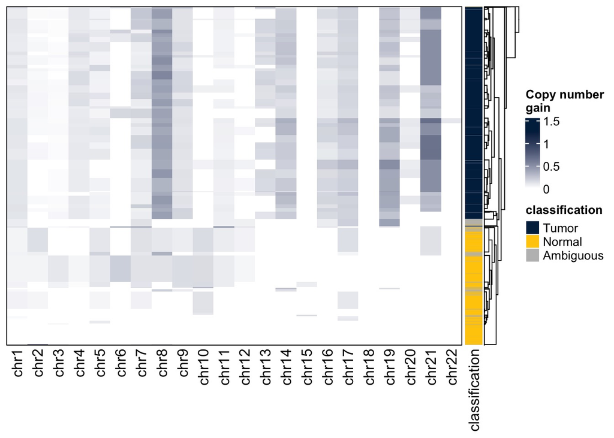

```r
# need to make a new annotation, since we want to annotate the rows here
annotation <- ComplexHeatmap::rowAnnotation(classification = annotation_df$combined_cnv_classification,
                                            col = list(classification = c("Tumor" = "#00274C", "Normal" = "#FFCB05", "Ambiguous" = "grey")))

# plot gains in cnv
plot_cnv_heatmap(classification_df,
                 cnv_col = "proportion_scaled_dupli",
                 annotation = annotation,
                 legend_title = "Copy number \ngain")
```

Below we make the same plot but with only the losses or deletions.

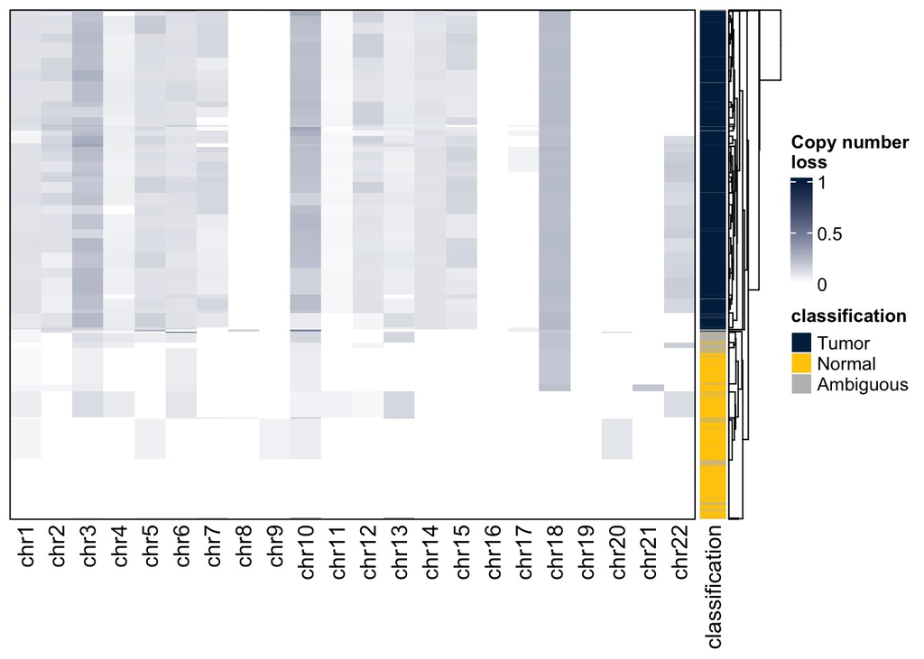

```r
# plot loss in cnv
plot_cnv_heatmap(classification_df,
                 cnv_col = "proportion_scaled_loss",
                 annotation = annotation,
                 legend_title = "Copy number \nloss")
```

In both of these plots, the majority of “Ambiguous” cells cluster between tumor and normal or with the normal cells.

## Create final tumor annotations

In looking at the plots, it looks like there might be some of the “Ambiguous” cells that should actually be classified as tumor cells. In particular, we expect those that have a gain in Chr8 are tumor cells, so let’s just look at Chr8 gains and see if we can find a cut off to use to categorize our “Unknown” cells.

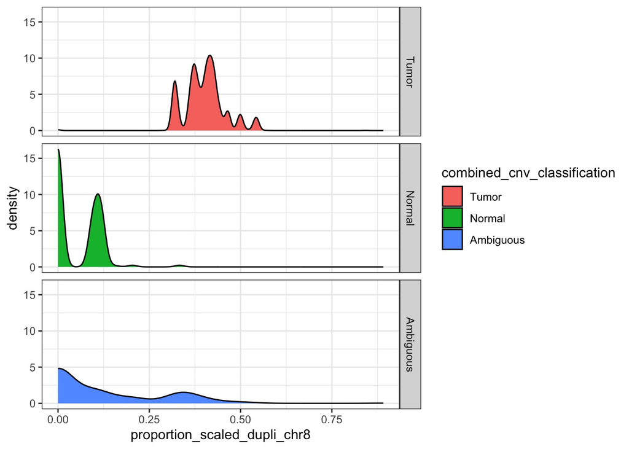

```r
# density plot of chr8 gains
ggplot(classification_df, aes(x = proportion_scaled_dupli_chr8, fill = combined_cnv_classification)) +
  geom_density() +
  facet_grid(rows = vars(combined_cnv_classification))
```

It looks like we have a pretty clear distinction between the `proportion_scaled_dupli_chr8` for normal and tumor cells, but there are a few bumps indicating some normal cells do have higher values for CNVs at Chr8 that are more similar tumor cells. Because of this, we will keep the “Ambiguous” cells as is and not try to classify them.

After validating that the cells classified as tumor by both `CopyKAT` and `InferCNV` show the expected expression patterns and CNV patterns as tumor cells, we can confidently label those cells as tumor cells. We will export these labels to the final annotations file for later use.

```r
# export final TSV with annotations
final_classifications <- new_classification_df |>
  dplyr::select(
    cell_barcode = barcodes,
    tumor_cell_classification = combined_cnv_classification
  ) |>
  unique()


readr::write_tsv(final_classifications, final_annotations_file)
```